# **Scraping data from Wikipedia**

by Artyom Kulikov

05/10/2020

# Introduction

In this project I will apply data scraping skills to retrieve a table of the Times Higher Education University World Ranking from a Wikipedia page. The given data will be summarized in an appropriate plot showing changes in rating of universities.

The first step is, as usual, loading necessary packages.

```r
library(rvest)
library(dplyr)
library(CGPfunctions)
library(ggthemes)
```

# Data scraping

To begin with, I download a data from a web-page, then I retrieve tables from it and check whether the table is one of my interest.

```r
wikidata <- "https://en.wikipedia.org/wiki/Times_Higher_Education_World_University_Rankings"

data1 <- wikidata%>%
  read_html()%>%
  html_table(fill=TRUE)

data1[[3]]
```

| Institution | 2010–11[42] | 2011–12[43] | 2012–13[44] | 2013–14[45] | 2014–15[46] | 2015–16[47] | 2016–17[48] | 2017-18[49] | 2018–19[50] | 2019–20[51] | 2020–21[52] |
| --- | --- | --- | --- | --- | --- | --- | --- | --- | --- | --- | --- |
| University of Oxford | 6 | 4 | 2 | 2 | 3 | 2 | 1 | 1 | 1 | 1 | 1 |
| Stanford University | 4 | 2 | 3 | 4 | 4 | 3 | 3 | 3 | 3 | 4 | 2 |
| Harvard University | 1 | 2 | 4 | 2 | 2 | 6 | 6 | 6 | 6 | 7 | 3 |
| California Institute of Technology | 2 | 1 | 1 | 1 | 1 | 1 | 2 | 3 | 5 | 2 | 4 |
| Massachusetts Institute of Technology | 3 | 7 | 5 | 5 | 6 | 5 | 5 | 5 | 4 | 5 | 5 |
| University of Cambridge | 6 | 6 | 7 | 7 | 5 | 4 | 4 | 2 | 2 | 3 | 6 |
| University of California, Berkeley | 8 | 10 | 9 | 8 | 8 | 13 | 10 | 18 | 15 | 13 | 7 |
| Yale University | 10 | 11 | 11 | 11 | 9 | 12 | 12 | 12 | 8 | 8 | 8 |
| Princeton University | 5 | 5 | 6 | 6 | 7 | 7 | 7 | 7 | 7 | 6 | 9 |
| University of Chicago | 13 | 9 | 10 | 9 | 11 | 10 | 10 | 9 | 10 | 9 | 10 |

[output cut: 40 more lines]

It seems that I’ve got the right table, so I can save it. However, it is seen that data in some columns with is not in appropriate type because of sign “-” meaning that in some year university dropped from the rating. It is better to transform such cases into NAs and then turn all data into one type. Also, it is better to rename columns as there are useless numbers of Wikipedia links.

```r
#Saving a table to data frame
rating <- data1[[3]]

#Replacing "-" with NAs
rating[,2:12] <- replace(rating[,2:12], rating[,2:12]=="-", NA)

#Turning data into numeric type
rating[,2:12] <- (lapply(rating[,2:12], as.numeric))

#Changing heads of columns
names(rating) <- c("University", "2010-2011", "2011-2012", "2012-2013", "2013-2014", "2014-2015", "2015-2016", "2016-2017", "2017-2018", "2018-2019", "2019-2020", "2020-2021")
```

Let’s see the table one more time to be sure that everything is fine.

```r
rating
```

| University | 2010-2011 | 2011-2012 | 2012-2013 | 2013-2014 | 2014-2015 | 2015-2016 | 2016-2017 | 2017-2018 | 2018-2019 | 2019-2020 | 2020-2021 |
| --- | --- | --- | --- | --- | --- | --- | --- | --- | --- | --- | --- |
| University of Oxford | 6 | 4 | 2 | 2 | 3 | 2 | 1 | 1 | 1 | 1 | 1 |
| Stanford University | 4 | 2 | 3 | 4 | 4 | 3 | 3 | 3 | 3 | 4 | 2 |
| Harvard University | 1 | 2 | 4 | 2 | 2 | 6 | 6 | 6 | 6 | 7 | 3 |
| California Institute of Technology | 2 | 1 | 1 | 1 | 1 | 1 | 2 | 3 | 5 | 2 | 4 |
| Massachusetts Institute of Technology | 3 | 7 | 5 | 5 | 6 | 5 | 5 | 5 | 4 | 5 | 5 |
| University of Cambridge | 6 | 6 | 7 | 7 | 5 | 4 | 4 | 2 | 2 | 3 | 6 |
| University of California, Berkeley | 8 | 10 | 9 | 8 | 8 | 13 | 10 | 18 | 15 | 13 | 7 |
| Yale University | 10 | 11 | 11 | 11 | 9 | 12 | 12 | 12 | 8 | 8 | 8 |
| Princeton University | 5 | 5 | 6 | 6 | 7 | 7 | 7 | 7 | 7 | 6 | 9 |
| University of Chicago | 13 | 9 | 10 | 9 | 11 | 10 | 10 | 9 | 10 | 9 | 10 |

[output cut: 40 more lines]

Since I finished data scraping, I can save the give table into RDS file.

```r
saveRDS(object = rating, file = 'Kulikov_THE_rating.RDS')
```

As I successfully retrieved the table and cleaned the data, it is now possible to do some work with it.

# Building a plot

In this part I will build a slopegraph that shows how first 10 rating positions of universities changed from 2011 to 2021.

Firstly, I need to limit our table to 10 rows.

```r
top10uni <- head(rating, 10)

top10uni%>%
  knitr:: kable()
```

| University | 2010-2011 | 2011-2012 | 2012-2013 | 2013-2014 | 2014-2015 | 2015-2016 | 2016-2017 | 2017-2018 | 2018-2019 | 2019-2020 | 2020-2021 |
| --- | --- | --- | --- | --- | --- | --- | --- | --- | --- | --- | --- |
| University of Oxford | 6 | 4 | 2 | 2 | 3 | 2 | 1 | 1 | 1 | 1 | 1 |
| Stanford University | 4 | 2 | 3 | 4 | 4 | 3 | 3 | 3 | 3 | 4 | 2 |
| Harvard University | 1 | 2 | 4 | 2 | 2 | 6 | 6 | 6 | 6 | 7 | 3 |
| California Institute of Technology | 2 | 1 | 1 | 1 | 1 | 1 | 2 | 3 | 5 | 2 | 4 |
| Massachusetts Institute of Technology | 3 | 7 | 5 | 5 | 6 | 5 | 5 | 5 | 4 | 5 | 5 |
| University of Cambridge | 6 | 6 | 7 | 7 | 5 | 4 | 4 | 2 | 2 | 3 | 6 |
| University of California, Berkeley | 8 | 10 | 9 | 8 | 8 | 13 | 10 | 18 | 15 | 13 | 7 |
| Yale University | 10 | 11 | 11 | 11 | 9 | 12 | 12 | 12 | 8 | 8 | 8 |
| Princeton University | 5 | 5 | 6 | 6 | 7 | 7 | 7 | 7 | 7 | 6 | 9 |
| University of Chicago | 13 | 9 | 10 | 9 | 11 | 10 | 10 | 9 | 10 | 9 | 10 |

I am interested only in 2011 and 2021 year, so other years should be deleted from the table. I make a copy of table and leave in the first one data for 2011 and in the second one for 2021. Also, I add new column with year as it is necessary for building a graph. Then, I unite these two tables into one.

```r
top10uni2<-top10uni

top10uni <- top10uni[,-c(3:12)]
year1 <- c("2011", "2011", "2011", "2011", "2011", "2011", "2011", "2011", "2011", "2011")
top10uni <- cbind(top10uni, year1)

top10uni2 <- top10uni2[,-c(2:11)]
year2 <- c("2021", "2021", "2021", "2021", "2021", "2021", "2021", "2021", "2021", "2021")
top10uni2 <- cbind(top10uni2, year2)

names(top10uni) <- c("uni", "rating", "year")
names(top10uni2) <- c("uni", "rating", "year")

topuni <- rbind(top10uni, top10uni2)

topuni%>%
  knitr:: kable()
```

| uni | rating | year |
| --- | --- | --- |
| University of Oxford | 6 | 2011 |
| Stanford University | 4 | 2011 |
| Harvard University | 1 | 2011 |
| California Institute of Technology | 2 | 2011 |
| Massachusetts Institute of Technology | 3 | 2011 |
| University of Cambridge | 6 | 2011 |
| University of California, Berkeley | 8 | 2011 |
| Yale University | 10 | 2011 |
| Princeton University | 5 | 2011 |
| University of Chicago | 13 | 2011 |
| University of Oxford | 1 | 2021 |
| Stanford University | 2 | 2021 |
| Harvard University | 3 | 2021 |
| California Institute of Technology | 4 | 2021 |
| Massachusetts Institute of Technology | 5 | 2021 |
| University of Cambridge | 6 | 2021 |
| University of California, Berkeley | 7 | 2021 |
| Yale University | 8 | 2021 |
| Princeton University | 9 | 2021 |
| University of Chicago | 10 | 2021 |

This is what I have after manipulations with data. Now, it is possible to construct our slopegraph. I decided to apply `newggslopegraph()` function from CGPfunctions package.

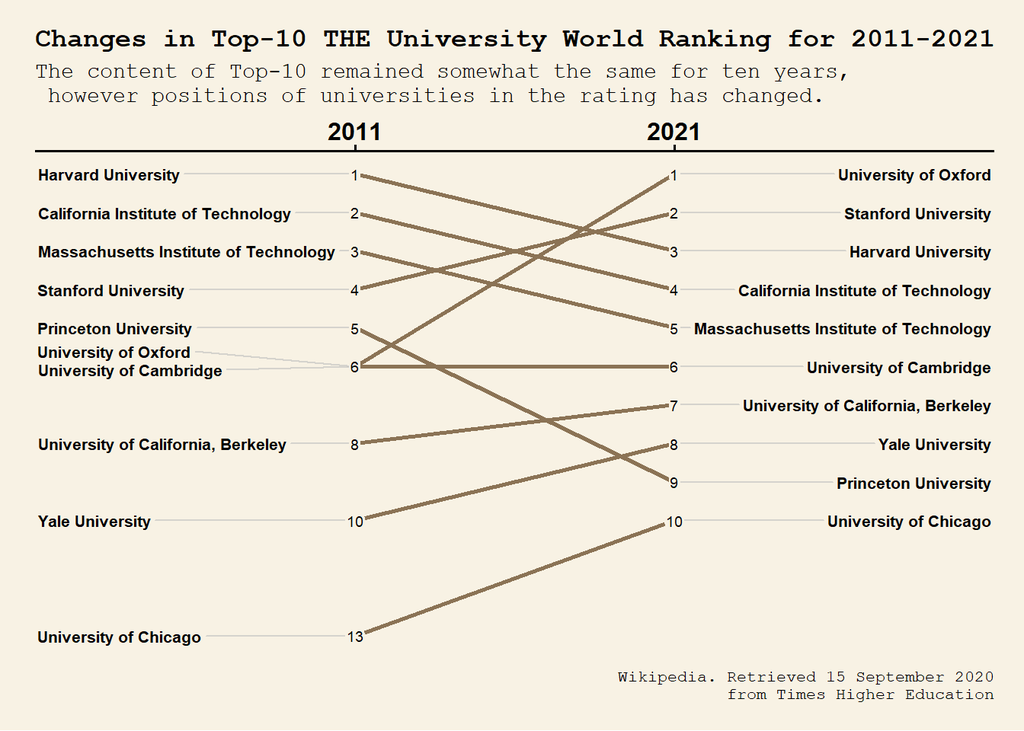

# Summary

As seen from the graph, Top-10 of 2011 and Top-10 of 2021 are rather similar in terms of names of universities that fill the rating. There are changes in the highest positions, while lower rankings did not change too much. By 10 years, 5 universities increased their rating, 4 fell to lower positions and 1 have stayed on the same place.